# Clustering_AllLife_Credit_card

## AllLife Credit Card Customer Segmentation

> **Background:** AllLife Bank wants to focus on its credit card customer base in the next financial year. They have been advised by their marketing research team, that the penetration in the market can be improved. Based on this input, the Marketing team proposes to run personalised campaigns to target new customers as well as upsell to existing customers. Another insight from the market research was that the customers perceive the support services of the back poorly. Based on this, the Operations team wants to upgrade the service delivery model, to ensure that customers queries are resolved faster. Head of Marketing and Head of Delivery both decide to reach out to the Data Science team for help.

> **Objective:** To identify different segments in the existing customer based on their spending patterns as well as past interaction with the bank.

### Key Questions:

> - How many different segments of customers are there?
> - How are these segments different from each other?
> - What are your recommendations to the bank on how to better market to and service these customers?

#### Data Description:

> Data is of various customers of a bank with their credit limit, the total number of credit cards the customer has, and different channels through which customer has contacted the bank for any queries, different channels include visiting the bank, online and through a call centre.

#### Steps to follow:

> - Perform univariate analysis on the data to better understand the variables at your disposal and to get an idea about the no of clusters.
> - Perform EDA and take insights out. pts 1 and 2 – (5)
> - Create visualizations to explore data and present the insights. (5)
> - Properly comment on the codes and provide explanations of the steps taken in the notebook. (5)
> - Execute hierarchical and K-means clustering (with different linkages) and do relevant visualisations (elbow plot, dendrograms etc) (10)
> - Perform a silhouette analysis. (5)

```python
# Import required libraries
import pandas as pd
from scipy.stats import zscore
import seaborn as sns
import numpy as np

import matplotlib.pyplot as plt
%matplotlib inline

from scipy.cluster.hierarchy import cophenet, dendrogram, linkage
from sklearn.cluster import KMeans
import scipy.cluster.hierarchy as sch
from scipy.spatial.distance import pdist
from sklearn.preprocessing import StandardScaler

from sklearn.cluster import AgglomerativeClustering
```

```python
# To display all the variable values / full output
from IPython.core.interactiveshell import InteractiveShell
InteractiveShell.ast_node_interactivity = "all"

# Ignore ipython warnings
import warnings
warnings.filterwarnings('ignore')
```

```python
# Read data and display the shape
df = pd.read_excel('Credit Card Customer Data.xlsx')
df.shape
```

```
(660, 7)
```

```python
df.head()
```

|  | Sl_No | Customer Key | Avg_Credit_Limit | Total_Credit_Cards | Total_visits_bank | Total_visits_online | Total_calls_made |
| --- | --- | --- | --- | --- | --- | --- | --- |
| 0 | 1 | 87073 | 100000 | 2 | 1 | 1 | 0 |
| 1 | 2 | 38414 | 50000 | 3 | 0 | 10 | 9 |
| 2 | 3 | 17341 | 50000 | 7 | 1 | 3 | 4 |
| 3 | 4 | 40496 | 30000 | 5 | 1 | 1 | 4 |
| 4 | 5 | 47437 | 100000 | 6 | 0 | 12 | 3 |

```python
# Drop serial number since it has all unique data
df.drop(['Sl_No','Customer Key'], axis=1, inplace=True)
df.shape
```

```
(660, 5)
```

```python
# Check null values
df.isnull().sum().any() # There is no null value in the dataset
```

```
False
```

```python
df.describe().transpose()
# The data distributed equally except avg_credit_limit and Total_visits_online columns
```

|  | count | mean | std | min | 25% | 50% | 75% | max |
| --- | --- | --- | --- | --- | --- | --- | --- | --- |
| Avg_Credit_Limit | 660.0 | 34574.242424 | 37625.487804 | 3000.0 | 10000.0 | 18000.0 | 48000.0 | 200000.0 |
| Total_Credit_Cards | 660.0 | 4.706061 | 2.167835 | 1.0 | 3.0 | 5.0 | 6.0 | 10.0 |
| Total_visits_bank | 660.0 | 2.403030 | 1.631813 | 0.0 | 1.0 | 2.0 | 4.0 | 5.0 |
| Total_visits_online | 660.0 | 2.606061 | 2.935724 | 0.0 | 1.0 | 2.0 | 4.0 | 15.0 |
| Total_calls_made | 660.0 | 3.583333 | 2.865317 | 0.0 | 1.0 | 3.0 | 5.0 | 10.0 |

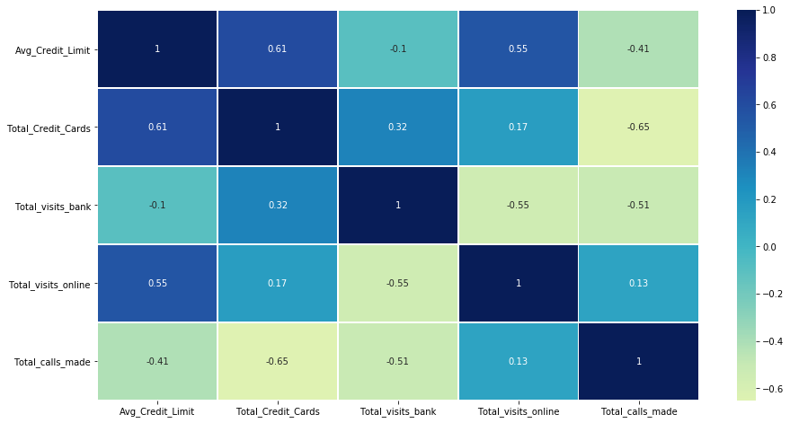

```python
# Finding a correlation b/w columns
df.corr()
plt.figure(figsize=(15,8))

sns.heatmap(df.corr(),
            annot=True,
            linewidths=.5,
            center=0,
            cbar=True,
            cmap="YlGnBu")
```

From above heatmap

- avg_credit_limit and total_credit_cards are positively correlated
- Total_visits_onlin and avg_credit_limit are positively correlated
- Total_calls_made and total_credit_cards are negatively correlated

## Plot the data

[figure not shown]

```python
plt.figure(figsize=(10,15))
sns.pairplot(df, height=2,aspect=2 , diag_kind='kde')
```

From above plot image, the data can be divided into 3 or 4 clusters.

## Standardize the data using Zscore

```python
sc = StandardScaler()

df_z = sc.fit_transform(df)
df_z.shape
```

[output not shown]

```python
df_z
```

[output not shown]

## K-Means Clustering

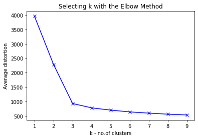

```python
clusters=range(1,10)
meanDistortions=[]

for k in clusters:
    model=KMeans(n_clusters=k, init='k-means++', random_state=0)
    model.fit(df_z)
    prediction=model.predict(df_z)
    meanDistortions.append(model.inertia_)

plt.plot(clusters, meanDistortions, 'bx-')
plt.xlabel('k - no.of clusters')
plt.ylabel('Average distortion')
plt.title('Selecting k with the Elbow Method')
```

The bend is coming down in 3 and 4th points. so let's create a cluster with k 3 and 4

### Silhoutte analysis

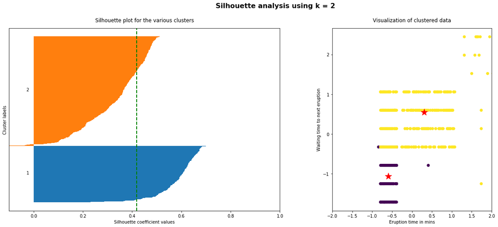

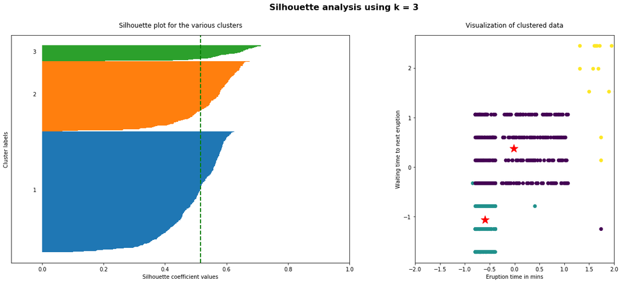

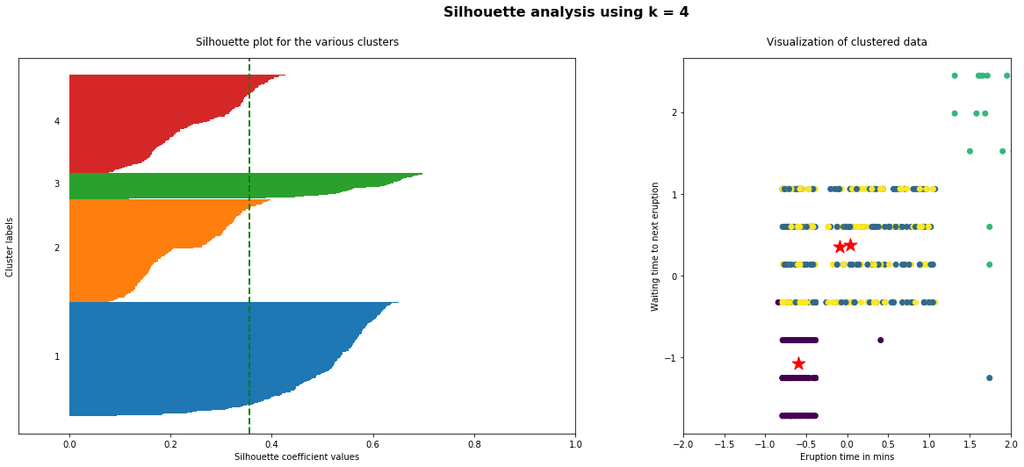

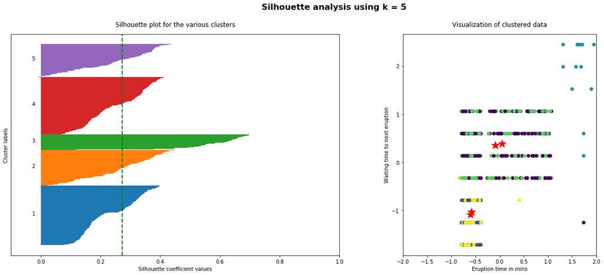

```python
from sklearn.metrics import silhouette_samples, silhouette_score

X_std = StandardScaler().fit_transform(df)
for i, k in enumerate([2, 3, 4, 5]):
    fig, (ax1, ax2) = plt.subplots(1, 2)
    fig.set_size_inches(18, 7)

    # Run the Kmeans algorithm
    km = KMeans(n_clusters=k)
    labels = km.fit_predict(X_std)
    centroids = km.cluster_centers_

    # Get silhouette samples
    silhouette_vals = silhouette_samples(X_std, labels)

    # Silhouette plot
    y_ticks = []
    y_lower, y_upper = 0, 0
    for i, cluster in enumerate(np.unique(labels)):
        cluster_silhouette_vals = silhouette_vals[labels == cluster]
        cluster_silhouette_vals.sort()
        y_upper += len(cluster_silhouette_vals)
        ax1.barh(range(y_lower, y_upper), cluster_silhouette_vals, edgecolor='none', height=1)
        ax1.text(-0.03, (y_lower + y_upper) / 2, str(i + 1))
        y_lower += len(cluster_silhouette_vals)

    # Get the average silhouette score and plot it
    avg_score = np.mean(silhouette_vals)
    ax1.axvline(avg_score, linestyle='--', linewidth=2, color='green')
    ax1.set_yticks([])
    ax1.set_xlim([-0.1, 1])
    ax1.set_xlabel('Silhouette coefficient values')
    ax1.set_ylabel('Cluster labels')
    ax1.set_title('Silhouette plot for the various clusters', y=1.02);

    # Scatter plot of data colored with labels
    ax2.scatter(X_std[:, 0], X_std[:, 1], c=labels)
    ax2.scatter(centroids[:, 0], centroids[:, 1], marker='*', c='r', s=250)
    ax2.set_xlim([-2, 2])
    ax2.set_xlim([-2, 2])
    ax2.set_xlabel('Eruption time in mins')
    ax2.set_ylabel('Waiting time to next eruption')
    ax2.set_title('Visualization of clustered data', y=1.02)
    ax2.set_aspect('equal')
    plt.tight_layout()
    plt.suptitle(f'Silhouette analysis using k = {k}',
                 fontsize=16, fontweight='semibold', y=1.05);
```

The coefficient can take values in the interval [-1, 1]. If it is 0 –> the sample is very close to the neighboring clusters. It it is 1 –> the sample is far away from the neighboring clusters. It it is -1 –> the sample is assigned to the wrong clusters.

Values b/w 0-1 is best score.

```python
# Building a model with K = 3

kmodel = KMeans(3)
kmodel.fit(df_z)
prediction = kmodel.fit_predict(df_z)
prediction
# # Append the prediction original dataset
# df['GROUP'] = prediction +1  # +1 is to start the grouping from 1 instead of 0
# df_z['GROUP'] = prediction + 1
# df.head()
```

[output not shown]

[output cut: 16 more lines]

### Visualize the clusters & Analyze the distribution

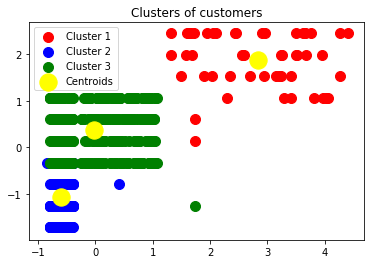

```python
plt.scatter(df_z[prediction == 0, 0], df_z[prediction == 0, 1], s = 100, c = 'red', label = 'Cluster 1')
plt.scatter(df_z[prediction == 1, 0], df_z[prediction == 1, 1], s = 100, c = 'blue', label = 'Cluster 2')
plt.scatter(df_z[prediction == 2, 0], df_z[prediction == 2, 1], s = 100, c = 'green', label = 'Cluster 3')
plt.scatter(kmodel.cluster_centers_[:, 0], kmodel.cluster_centers_[:, 1], s = 300, c = 'yellow', label = 'Centroids')
plt.title('Clusters of customers')
plt.legend()
plt.show()
```

```python
df.groupby(['GROUP']).mean()
```

[output not shown]

## Hierarchical Clustering

```python
aggmodel = AgglomerativeClustering(n_clusters=3, affinity='euclidean',  linkage='average')
aggmodel.fit(df_z)
```

```
AgglomerativeClustering(affinity='euclidean', compute_full_tree='auto',
                        connectivity=None, distance_threshold=None,
                        linkage='average', memory=None, n_clusters=3)
```

```python
df['GROUP'] = aggmodel.labels_ + 1 # +1 is to start the grouping from 1 instead of 0
df.head(10)
```

|  | Avg_Credit_Limit | Total_Credit_Cards | Total_visits_bank | Total_visits_online | Total_calls_made | GROUP |
| --- | --- | --- | --- | --- | --- | --- |
| 0 | 100000 | 2 | 1 | 1 | 0 | 1 |
| 1 | 50000 | 3 | 0 | 10 | 9 | 3 |
| 2 | 50000 | 7 | 1 | 3 | 4 | 1 |
| 3 | 30000 | 5 | 1 | 1 | 4 | 1 |
| 4 | 100000 | 6 | 0 | 12 | 3 | 2 |
| 5 | 20000 | 3 | 0 | 1 | 8 | 3 |
| 6 | 100000 | 5 | 0 | 11 | 2 | 2 |
| 7 | 15000 | 3 | 0 | 1 | 1 | 3 |
| 8 | 5000 | 2 | 0 | 2 | 2 | 3 |
| 9 | 3000 | 4 | 0 | 1 | 7 | 3 |

```python
df['GROUP'].value_counts()
```

```
1    386
3    224
2     50
Name: GROUP, dtype: int64
```

### Find out Linkage maxtrix and Plot the dendrogram

```python
# Correlation between the distance(Average distance)
Z = linkage(df, metric='euclidean', method='average')
c, coph_dists = cophenet(Z , pdist(df))
c
# closer it is to 1, the better is the clustering
```

```
0.9037157591091822
```

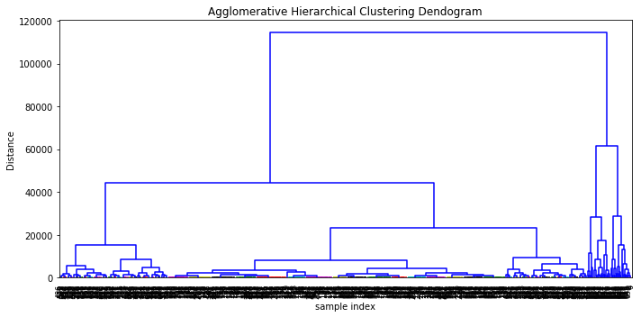

```python
plt.figure(figsize=(10, 5))
plt.title('Agglomerative Hierarchical Clustering Dendogram')
plt.xlabel('sample index')
plt.ylabel('Distance')
dendrogram(Z, leaf_rotation=90.,color_threshold = 40, leaf_font_size=8. )
plt.tight_layout()
```

### Truncate the Dendrogram

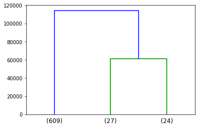

```python
dendrogram(
    Z,
    truncate_mode='lastp',  # show only the last p merged clusters
    p=3,  # show only the last p merged clusters
)
plt.show()
```

### Dendogram with ward linkage

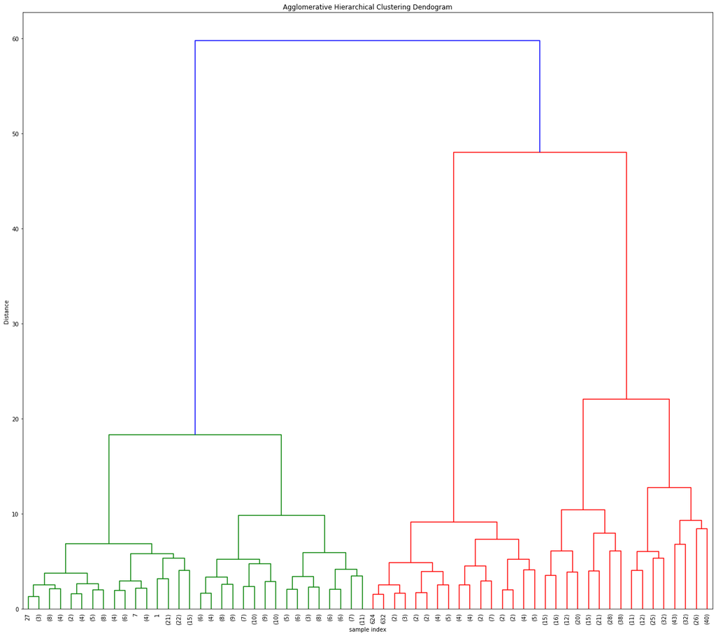

```python
plt.figure(figsize=(18, 16))
plt.title('Agglomerative Hierarchical Clustering Dendogram')
plt.xlabel('sample index')
plt.ylabel('Distance')
Z = linkage(df, 'ward')
dendrogram(Z,leaf_rotation=90.0,p=5,color_threshold=52,leaf_font_size=10,truncate_mode='level')
plt.tight_layout()
```

## Insights and plan of action

```python
df.groupby(['GROUP']).mean()
```

[output not shown]

```python
df['GROUP'].value_counts()
```

```
1    386
3    224
2     50
Name: GROUP, dtype: int64
```

# Insights:

Insights from both the cluster:

> 1. Cluster 2 is set of customers who has highest credit limit and more number of credit cards. Their bank visits will be less but they use the online banking. also number of calls made will be lesser than other customers. These customers are **Top spending / Long term / Experienced / Educated Customers .**
> 2. Cluster 1 is set of customers who has medium credit limit and no.of credit cards. Frequent visitor to bank, also they are less educated since they are not using online bank. **Medium spending / Frequent bank visitors / Less educated Customers**
> 3. Cluster 3 is set of customers who has low credit limi and lesser credit cards. also they are educated since they use online and make a call to bank. **Low spending / Frequent call makers / educated Customers**